# ochre_intro

Holly Kirk

26 October 2017

# Introduction

“Welcome to all people… To this land of ochre” - Ruby Hunter

The **ochre** package contains colour palettes inspired by the Australian landscape, iconic Australian artists and images.

# Installation

```r
install.packages("ochre")
```

**Or the development version**

```r
devtools::install_github("ropenscilabs/ochre")
```

# The Palettes

## Usage

```r
library(ochRe)

# See names of all palettes
names(ochre_palettes)
```

```
##  [1] "namatjira_qual"            "namatjira_div"
##  [3] "mccrea_melbcollinsst_1841" "parliament"
##  [5] "tasmania"                  "nolan_ned"
##  [7] "winmar"                    "olsen_qual"
##  [9] "olsen_div"                 "williams_pilbara"
## [11] "healthy_reef"              "emu_woman_paired"
```

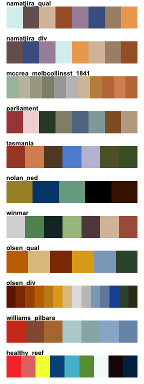

[figure not shown]

```r
pal_names <- names(ochre_palettes)

par(mfrow=c(11, 1), lheight = 2, mar=rep(1, 4), adj = 0)
for (i in 1:length(ochre_palettes)){
    viz_palette(ochre_palettes[[i]], pal_names[i])
}
```

### namatjira

This palette is based on the painting “Twin Ghosts”" by Albert Namatjira. It has eight colours.

[figure not shown]

### mccrea_melbcollinsst_1841

This palette is based on the painting “Melbourne, Collins St, 1841” by Georgiana McCrae. It has eleven colours.

[figure not shown]

mccrea_melbcollinsst_1841

### parliament

This palette is based on based on the tapestry in the Great Hall of Parliament House, of a landscape by Arthur Boyd - Untitled (Shoalhaven Landscape), as well as the colours of the and House of Representatives and the Senate. It has eight colours.

[figure not shown]

Untitled (Shoalhaven Landscape)

Parliament House: https://www.peo.gov.au/learning/closer-look/australias-parliament-house/a-place-for-the-parliament.html

### tasmania

This palette is based on colours in the bay of fires and cradle mountain. It has seven colours.

### nolan_ned

This palette is based on the painting “Ned Kelly”, 1946, by Sidney Nolan. It has five colours.

[figure not shown]

Ned Kelly